# A Simple Example for rnw_to_rmd Function

Yinxiang Huang Beihang University 21375146@buaa.edu.cn

2024-10-02

Abstract

Many of the early R packages used Sweave to write vigneettes, which will be shown to users as pdf format on CRAN. However, as time goes on, R Markdown, a lightweight markup language, has begun to gradually replace Sweave and better present content on CRAN in the form of HTML.

In order to help many R package developers who haven’t used R Markdown or don’t have time to do the format conversion manually to migrate from Sweave to R Markdown, `texor` helps people automate this conversion process.

# Introduction to Sweave and Knitr

Sweave options will be automatically converted to knitr.

To remove warning messages, setup code chunk use knitr option `warning=FALSE`.

When the option OutDec is not `.`, put numbers in `\text`.

```r
options(OutDec = ',')
```

This is the first test. abc 0,6 def

another test $a = 0,6$.

and the last one $a = 0.6$.

```r
options(OutDec = '.')
```

This is the second test. abc 0.6 def

another test $a = 0.6$.

and the last one $a = 0.6$.

Inline R code in verbatim environment will also be converted.

```r
try this:
2
```

# Generate Image from R Code Chunk

The first image:

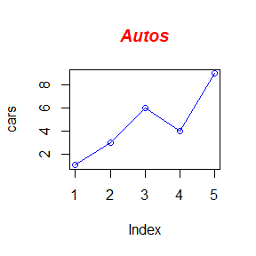

Figure 1: A fig o cars

```r
# Define the cars vector with 5 values
cars <- c(1, 3, 6, 4, 9)
plot(cars, type="o", col="blue")
title(main="Autos", col.main="red", font.main=4)
```

Let’s test another image from R code chunk:

[figure not shown]

Figure 2: matrix package’s image

```r
if (system.file(package = "Matrix") == "") {
  install.packages("Matrix")
  library(Matrix)
} else {
  library(Matrix)
}
data(CAex, package = "Matrix")
print(image(CAex, main = "image(CAex)")) # print(.) needed for Sweave
```

Show R logo from file:

[figure not shown]

Figure 3: R logo

# References

Huang, Yinxiang. 2024. *A Title for Bib in Texor*. UNKNOWN. https://github.com/Abhi-1U/texor/.